# Effect of ocean acidification on Symbiodinium gene expression

Olivia Nieves and Maria Ingersoll

3/23/2021

## Introduction

In this project we reanalyze the data from Davies et al. 2018. First, we use DESeq2 analysis in order to analyze gene expression differences in Clade C of the dinoflagellate family Symbiodiniaceae that associate with the coral *Siderastrea siderea* when exposed to a high level of ocean acidification. We compare P2553 condition (a highly acidic environment) to a control and found that, under these conditions, Symbiodiniaceae upregulate 14 and downregulate 3 genes when compared to the control (rlog fold change value averaged across all samples from each condition; adjusted p-value of less than 0.1). Via heatmap, we used less stringent conditions to visualize the trends of all differentially expressed genes (non-adjusted p-value of less than 0.1) in each condition, demonstrating distinct clustering by treatment condition. Next, we use GO Enrichment analysis to determine which GO terms are over/under-represented in our samples under acidification stress. Finally, we used GO term rank-based enrichment analysis to determine functional processes that differ within the symbiont under the two conditions.

## Version Control

R Version: 4.0.4  
DESeq2: 1.30.1  
affycoretools: 1.62.0 arrayQualityMetrics: 3.46.0  
genefilter: 1.72.1 Biobase: 2.50.0 ggplot2: 3.3.3 dplyr: 1.0.5 pheatmap: 1.0.12 vegan: 2.5-7 ggrepel: 0.9.1 tidyverse: 1.3.0 RColorBrewer: 1.1-2 gplots: 3.1.1 gsubfn: 0.7 ape: 5.4-1

## Data Analysis

- Set your working directory.

```r
setwd("/Users/mariaingersoll/Desktop/BU2020-2021/Ecol_and_Enviro_Genomics/BI586-git/OA_assign2")
```

- Library the necessary packages.

```r
library(DESeq2)
library(affycoretools)
library(arrayQualityMetrics)
library(genefilter)
library(Biobase)
library(ggplot2)
library(dplyr)
library(pheatmap)
library(vegan)
library(ggrepel)
library(tidyverse)
library(RColorBrewer)
library(gplots)
library(gsubfn)
library(ape)
```

- Look for outliers. First, read in counts then create arrayQualityMetrics report and check HTML export file for outliers. NOTE: no outliers found in our data set.

```r
countData <- read.table("1.Assign2_GE_Sym_OA.csv", sep=",", header=T)
row.names(countData)=countData$X
countData$X=NULL
length(countData[,1])
```

```
## [1] 41850
```

```r
treat=c( "Control", "P2553", "P2553", "Control")
g=data.frame(treat)
colData<- g

dds<-DESeqDataSetFromMatrix(countData=countData, colData=g, design=~treat)

vsd.ge=assay(vst(dds))
rl=vst(dds)
e=ExpressionSet(assay(rl), AnnotatedDataFrame(as.data.frame(colData(rl))))
arrayQualityMetrics(e,intgroup=c("treat"),force=T)
```

- Re-read in counts and Plot count values as a barplot. This is a sanity check to assure that our samples contain relatively similar count values.

```r
countData <- read.table("1.Assign2_GE_Sym_OA.csv", sep=",", header=T)
row.names(countData)=countData$X
countData$X=NULL
length(countData[,1])
```

```
## [1] 41850
```

```r
totalCounts=colSums(countData)
totalCounts
```

```
## Control_1   P2553_1   P2553_2 Control_2
##  23609939  17129845  23263765  24272033
```

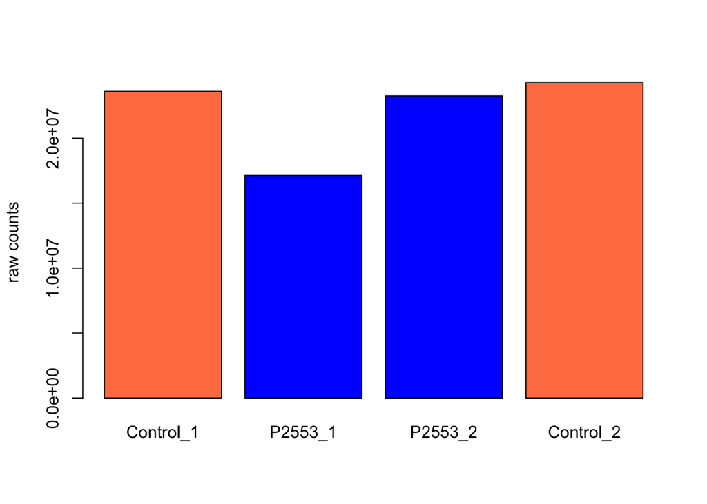

```r
barplot(totalCounts, col=c("coral", "blue", "blue", "coral"), ylab="raw counts")
```

- We next perform DESeq analysis to see how our data varies by treatment (by calculating the log2foldchange, the pvalue, and the adjusted pvalue for each gene). Re-read in counts then perform DESeq function.

```r
countData <- read.table("1.Assign2_GE_Sym_OA.csv", sep=",", header=T)
row.names(countData)=countData$X
countData$X=NULL
length(countData[,1])
```

```
## [1] 41850
```

```r
treat=c( "Control", "P2553", "P2553", "Control")
g=data.frame(treat)
colData<- g


dds<-DESeqDataSetFromMatrix(countData=countData, colData=colData, design=~treat)

dds<-DESeq(dds)
res <- results(dds)
```

- Look at dispersion plot to visualize the trend of our data.

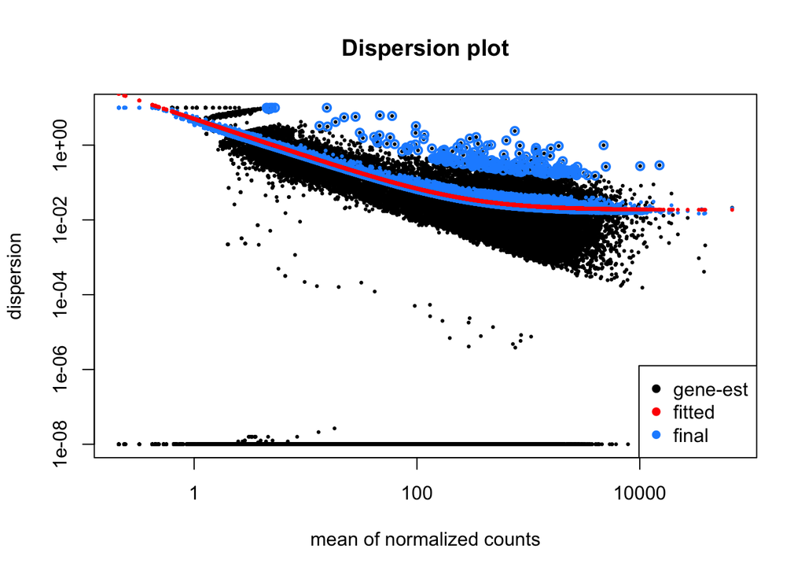

```r
plotDispEsts(dds, main="Dispersion plot")
```

```r
resP2553 <- results(dds, contrast=c("treat","P2553","Control"))
table(resP2553$padj<0.01)
```

```
##
## FALSE  TRUE
## 28045    11
```

```r
summary(resP2553)
```

```
##
## out of 41849 with nonzero total read count
## adjusted p-value < 0.1
## LFC > 0 (up)       : 14, 0.033%
## LFC < 0 (down)     : 3, 0.0072%
## outliers [1]       : 0, 0%
## low counts [2]     : 13793, 33%
## (mean count < 11)
## [1] see 'cooksCutoff' argument of ?results
## [2] see 'independentFiltering' argument of ?results
```

```r
nrow(resP2553[resP2553$padj<0.05 & !is.na(resP2553$padj),])
```

```
## [1] 12
```

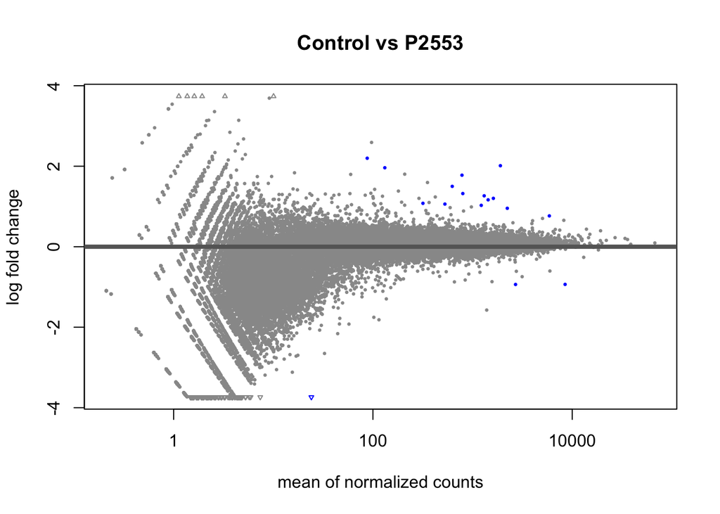

```r
plotMA(resP2553, main="Control vs P2553")
```

- Use pairwise comparison to determine the amount of up and downregulated genes in the P2553 treatment.

```r
results <- as.data.frame(resP2553)

nrow(resP2553[resP2553$padj<0.1 & resP2553$log2FoldChange > 0 & !is.na(resP2553$padj),])
```

```
## [1] 14
```

```r
nrow(resP2553[resP2553$padj<0.1 & resP2553$log2FoldChange < 0 & !is.na(resP2553$padj),])
```

```
## [1] 3
```

```r
write.table(resP2553, file="P2553.txt", quote=F, sep="\t")

cd <- read.table("P2553.txt")
```

- Get p values.

```r
val2553=cbind(resP2553$pvalue, resP2553$padj)
colnames(val2553)=c("pval.2553", "padj.2553")
length(val2553[,1])
```

```
## [1] 41850
```

```r
table(complete.cases(val2553))
```

```
##
## FALSE  TRUE
## 13794 28056
```

- Make rlogdata and pvals table.

```r
rlog=rlogTransformation(dds, blind=TRUE)
rld=assay(rlog)
head(rld)
```

```
##                  Control_1     P2553_1     P2553_2   Control_2
## isogroup427488  1.30530086  1.33860218  1.30539930  1.33960949
## isogroup352712 -0.44340231 -0.43495175 -0.44337332 -0.43186043
## isogroup335848 -0.07374067 -0.06524516 -0.07370375 -0.05658652
## isogroup102625  0.25421952  0.25649286  0.24794138  0.26498754
## isogroup4169    0.92187833  0.91821802  0.91582749  0.93190891
## isogroup319152  0.54758943  0.56441081  0.54764704  0.57052182
```

```r
colnames(rld)=paste(colData$treat)
head(rld)
```

```
##                    Control       P2553       P2553     Control
## isogroup427488  1.30530086  1.33860218  1.30539930  1.33960949
## isogroup352712 -0.44340231 -0.43495175 -0.44337332 -0.43186043
## isogroup335848 -0.07374067 -0.06524516 -0.07370375 -0.05658652
## isogroup102625  0.25421952  0.25649286  0.24794138  0.26498754
## isogroup4169    0.92187833  0.91821802  0.91582749  0.93190891
## isogroup319152  0.54758943  0.56441081  0.54764704  0.57052182
```

```r
length(rld[,1])
```

```
## [1] 41850
```

```r
rldpvals=cbind(rld,val2553)
head(rldpvals)
```

```
##                    Control       P2553       P2553     Control pval.2553
## isogroup427488  1.30530086  1.33860218  1.30539930  1.33960949 0.9946332
## isogroup352712 -0.44340231 -0.43495175 -0.44337332 -0.43186043 0.9061950
## isogroup335848 -0.07374067 -0.06524516 -0.07370375 -0.05658652 0.7696045
## isogroup102625  0.25421952  0.25649286  0.24794138  0.26498754 0.6195770
## isogroup4169    0.92187833  0.91821802  0.91582749  0.93190891 0.6000288
## isogroup319152  0.54758943  0.56441081  0.54764704  0.57052182 0.8831739
##                padj.2553
## isogroup427488        NA
## isogroup352712        NA
## isogroup335848        NA
## isogroup102625        NA
## isogroup4169          NA
## isogroup319152        NA
```

```r
dim(rldpvals)
```

```
## [1] 41850     6
```

```r
table(complete.cases(rldpvals))
```

```
##
## FALSE  TRUE
## 13794 28056
```

```r
write.csv(rldpvals, "OA_assign2_RLDandPVALS.csv", quote=F)

colnames(rld)=paste(colData$treat)
head(rld)
```

```
##                    Control       P2553       P2553     Control
## isogroup427488  1.30530086  1.33860218  1.30539930  1.33960949
## isogroup352712 -0.44340231 -0.43495175 -0.44337332 -0.43186043
## isogroup335848 -0.07374067 -0.06524516 -0.07370375 -0.05658652
## isogroup102625  0.25421952  0.25649286  0.24794138  0.26498754
## isogroup4169    0.92187833  0.91821802  0.91582749  0.93190891
## isogroup319152  0.54758943  0.56441081  0.54764704  0.57052182
```

- Make a sample distance heat map in order to look at overall similarities between our samples using raw log values in count data.

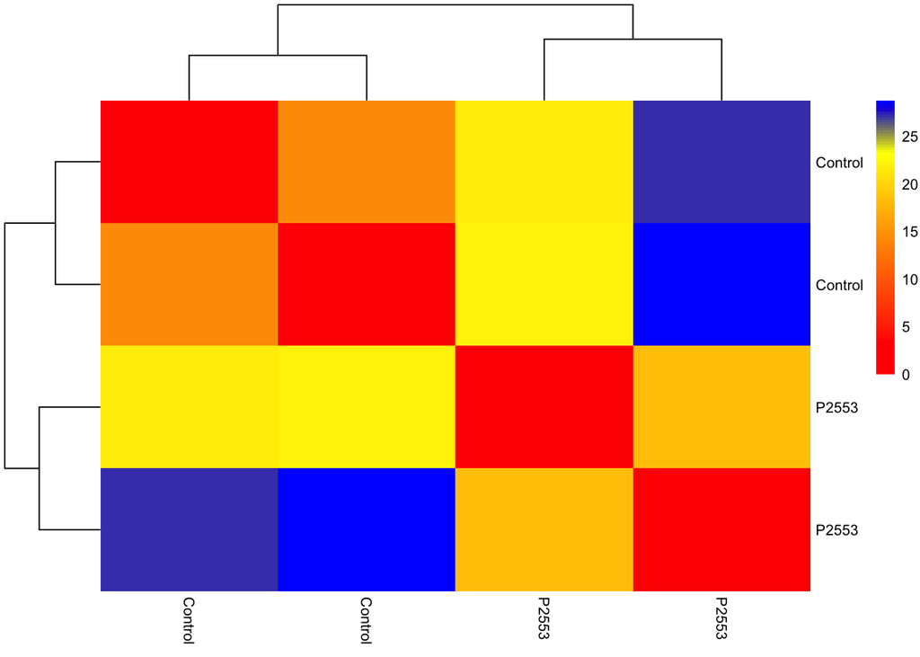

```r
rldpvals <- read.csv(file="OA_assign2_RLDandPVALS.csv", row.names=1)
rld=rldpvals[,1:4]

sampleDists <- dist(t(rld))
sampleDistMatrix <- as.matrix( sampleDists )
treat=c( "Control", "P2553", "Control", "P2553")
colnames(sampleDistMatrix)=paste(treat)
rownames(sampleDistMatrix)=paste(treat)

heat.colors = colorRampPalette(rev(c("blue","yellow","red")),bias=0.3)(100)
pheatmap(sampleDistMatrix,color = heat.colors,cex=0.9,border_color=NA,cluster_rows=T,cluster_cols=T)
```

- Plot PCA of the data to visualize non-biased clustering of all the samples.

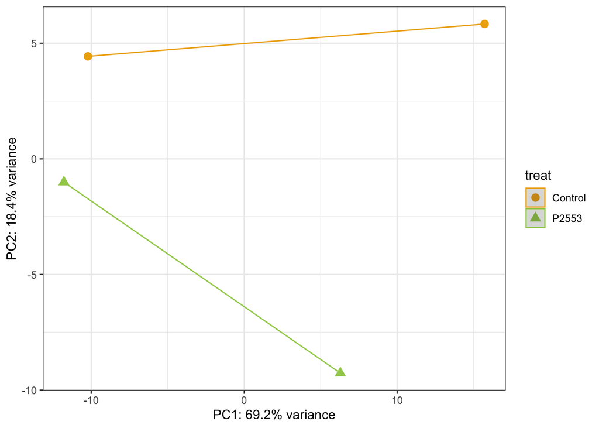

```r
rld_t=t(rld)
pca <- prcomp(rld_t,center = TRUE)
li <- pca$sdev^2 / sum(pca$sdev^2)
pc1v <- round(li[1] * 100, 1)
pc2v <- round(li[2] * 100, 1)
pca_s <- as.data.frame(pca$x)
pca_s <- pca_s[,c(1,2)]
pca_s$Samples = row.names(pca_s)
pca_s$treat=colData$treat

cbPalette <- c("darkgoldenrod2",  "darkolivegreen3", "dodgerblue3")
ggplot(pca_s, aes(PC1, PC2, color = treat, pch = treat)) +
  geom_point(size=3) +
  scale_colour_manual(values=cbPalette)+
  theme_bw() +
  geom_polygon(alpha=.2)+
  xlab(paste0("PC1: ",pc1v,"% variance")) +
  ylab(paste0("PC2: ",pc2v,"% variance"))
```

```r
adonis(pca$x ~ treat, data = pca_s, method='eu', na.rm = TRUE)
```

```
##
## Call:
## adonis(formula = pca$x ~ treat, data = pca_s, method = "eu",      na.rm = TRUE)
##
## Permutation: free
## Number of permutations: 23
##
## Terms added sequentially (first to last)
##
##           Df SumsOfSqs MeanSqs F.Model      R2 Pr(>F)
## treat      1    154.10   154.1 0.50393 0.20126 0.6667
## Residuals  2    611.59   305.8         0.79874
## Total      3    765.69                 1.00000
```

- Create a list of all the genes that have a pval <=0.1 in order to analyze the overall trends of differentially expressed genes in all our samples. Also create a list of all the genes that have a padj <=0.1 in order to visualize the most differentially regulated genes

```r
rldpvals_10 = filter(rldpvals, pval.2553 <= 0.1, preserve = TRUE)
length(rldpvals_10[,1])
```

```
## [1] 903
```

```r
length(rldpvals[,1])
```

```
## [1] 41850
```

```r
rld_10 = rldpvals_10[,1:4]
rld_10 = rownames_to_column(rld_10, var = "Gene_ID")

rldpadj_10 = filter(rldpvals, padj.2553 <= 0.1, preserve = TRUE)
length(rldpadj_10[,1])
```

```
## [1] 17
```

```r
rld_10_adj = rldpadj_10[,1:4]
rld_10_adj = rownames_to_column(rld_10_adj, var = "Gene_ID")
```

- Make the variable “gene” with the gene symbol called description. Then join the two variables rld_10 and gene by “Gene_ID.” Do the same with rld_10_adj and gene

```r
gene = read.delim("davies_cladeC_iso2gene.tab.txt", sep = "\t")%>%
  mutate(Description = gsub(".* GN=", "", Description)) %>%
  mutate(Description = gsub(" .*", "", Description))
head(gene)
```

```
##          Gene_ID Description
## 1 isogroup283428        THIC
## 2 isogroup218718      uap1l1
## 3  isogroup45613        Nfs1
## 4 isogroup218953      ngoBIM
## 5 isogroup269336       pgam5
## 6  isogroup35073      d2hgdh
```

```r
sigDEG = rld_10 %>%
  left_join(gene) %>%
  mutate(Description = make.names(Description, unique = TRUE)) %>%
  column_to_rownames(var = "Description") %>%
  dplyr::select(-Gene_ID) %>%
  drop_na() %>%
  dplyr::select(sort(current_vars()))
head(sigDEG)
```

```
##         Control Control.1    P2553  P2553.1
## PGM    1.239430  1.288756 1.234280 1.233238
## Ars2   1.177176  1.185873 1.153592 1.152625
## DIT2.1 1.133341  1.165468 1.121894 1.120935
## NA.    2.113899  2.100433 2.143217 2.164849
## DHX9   1.285867  1.311507 1.268503 1.267460
## DHX57  1.155839  1.176081 1.138369 1.137415
```

```r
nrow(sigDEG)
```

```
## [1] 903
```

```r
sigDEG_adj = rld_10_adj %>%
  left_join(gene) %>%
  mutate(Description = make.names(Description, unique = TRUE)) %>%
  column_to_rownames(var = "Description") %>%
  dplyr::select(-Gene_ID) %>%
  drop_na() %>%
  dplyr::select(sort(current_vars()))
head(sigDEG_adj)
```

```
##        Control Control.1    P2553  P2553.1
## NA.   4.666695  4.641670 4.377025 4.367016
## NA..1 6.149804  5.977626 6.550438 6.555416
## HLF   6.666956  6.571917 7.131042 7.226597
## Rpa3  8.040189  7.989171 8.391635 8.551440
## NA..2 8.581381  8.828220 9.143178 9.303897
## NA..3 8.835677  8.722255 9.444868 9.598291
```

```r
nrow(sigDEG_adj)
```

```
## [1] 17
```

- Make a heatmap of all the differentially expressed genes (DEGs) of both the less stringent (pval) and more stringent (padj) conditions.

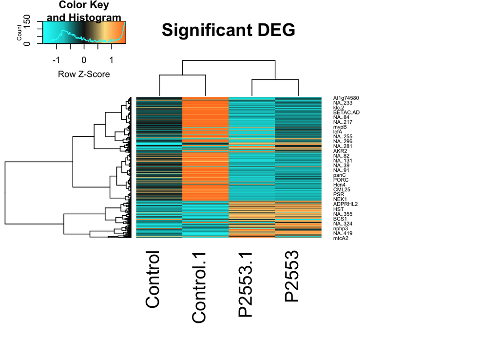

```r
col0=colorRampPalette(rev(c("chocolate1","#FEE090","grey10", "cyan3","cyan")))(100)
heatmap_sigDEG = heatmap.2(as.matrix(sigDEG), col = col0, Rowv = TRUE, Colv = TRUE, scale = "row",
                           dendrogram = "both",
                           trace = "none",
                           main = "Significant DEG",
                           margin = c(10,15))
```

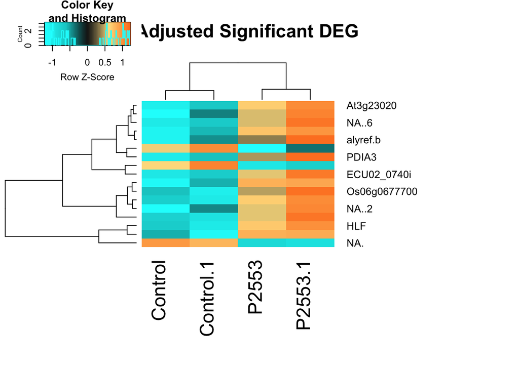

```r
heatmap_sigDEG = heatmap.2(as.matrix(sigDEG_adj), col = col0, Rowv = TRUE, Colv = TRUE, scale = "row",
                           dendrogram = "both",
                           trace = "none",
                           main = "P-Adjusted Significant DEG",
                           margin = c(10,15))
```

- Make a GO table of the properly formatted isoforms and logfoldchange info for further analysis.

```r
go_input_P2553 = cd %>%
  tibble::rownames_to_column(var = "iso") %>%
  mutate(mutated_p = -log(pvalue)) %>%
  mutate(mutated_p_updown = ifelse(log2FoldChange < 0, mutated_p*-1, mutated_p*1)) %>%
  na.omit() %>%
  select(iso, mutated_p_updown)
head(go_input_P2553)
```

```
##                 iso mutated_p_updown
## 5405  isogroup69667        0.9309091
## 6510 isogroup113396        0.2917369
## 6678  isogroup74103        0.7990304
## 6680 isogroup159645        0.1019128
## 6854 isogroup158356       -0.2295007
## 7014 isogroup171985        1.3807504
```

```r
colnames(go_input_P2553) <- c("gene", "pval")
head(go_input_P2553)
```

```
##                gene       pval
## 5405  isogroup69667  0.9309091
## 6510 isogroup113396  0.2917369
## 6678  isogroup74103  0.7990304
## 6680 isogroup159645  0.1019128
## 6854 isogroup158356 -0.2295007
## 7014 isogroup171985  1.3807504
```

```r
write.csv(go_input_P2553, file="P2553_GO.csv", quote=F, row.names=FALSE)
```

- GO term enrichment analysis. Repeat for each goDivision: either MF, or BP, or CC.

```r
input="P2553_GO.csv"
goAnnotations="davies_cladeC_iso2go.tab"
goDatabase="go.obo"
goDivision_1="MF"
source("gomwu.functions.R")

gomwuStats(input, goDatabase, goAnnotations, goDivision_1,
  perlPath="perl",
  largest=0.1,
    smallest=5,
    clusterCutHeight=0.25)
```

```
## Continuous measure of interest: will perform MWU test
## 3  GO terms at 10% FDR
```

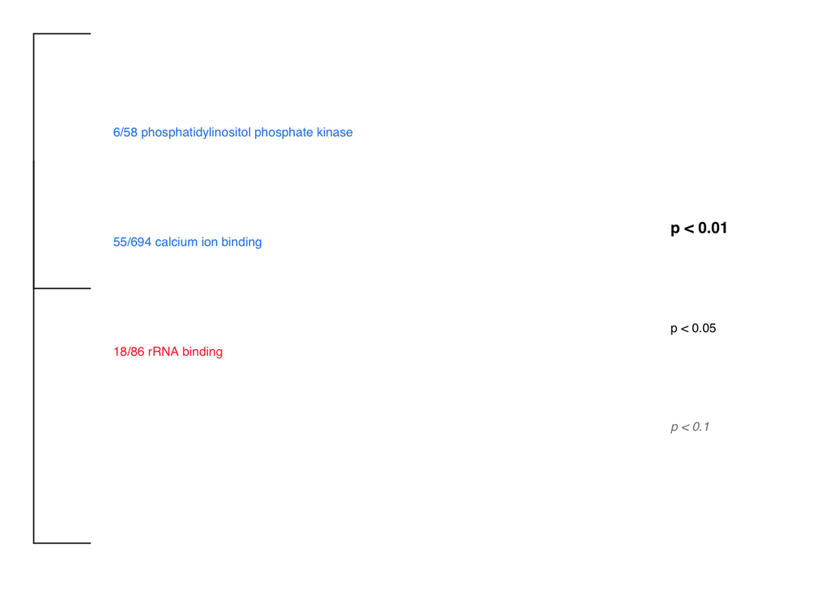

```
## GO terms dispayed:  3
## "Good genes" accounted for:  79 out of 1131 ( 7% )
```

```r
results=gomwuPlot(input,goAnnotations,goDivision_1,
    absValue=-log(0.05,10),
    level1=0.1,
    level2=0.05,
    level3=0.01,
    txtsize=1.2,
    treeHeight=0.5,
    colors=c("dodgerblue2","firebrick1","skyblue2","lightcoral")
)
```

```r
results
```

```
##                                                           pval direction
## 18/86 rRNA binding                                  0.03480036         1
## 55/694 calcium ion binding                          0.01411872         0
## 6/58 phosphatidylinositol phosphate kinase activity 0.01411872         0
##                                                           color
## 18/86 rRNA binding                                   firebrick1
## 55/694 calcium ion binding                          dodgerblue2
## 6/58 phosphatidylinositol phosphate kinase activity dodgerblue2
```

```r
input="P2553_GO.csv"
goAnnotations="davies_cladeC_iso2go.tab"
goDatabase="go.obo"
goDivision_2="BP"
source("gomwu.functions.R")

gomwuStats(input, goDatabase, goAnnotations, goDivision_2,
  perlPath="perl",
  largest=0.1,
    smallest=5,
    clusterCutHeight=0.25)
```

```
## Continuous measure of interest: will perform MWU test
## 11  GO terms at 10% FDR
```

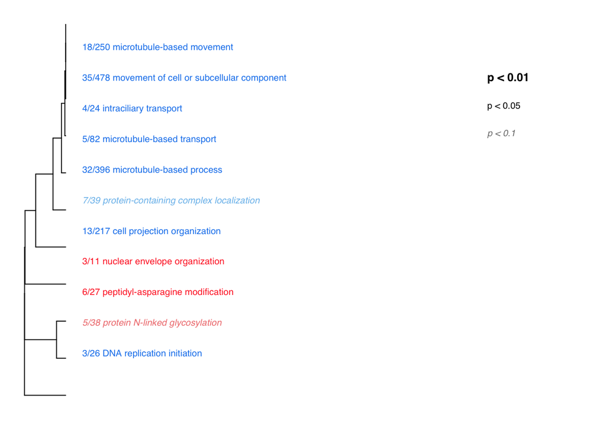

```
## GO terms dispayed:  11
## "Good genes" accounted for:  67 out of 1052 ( 6% )
```

```r
results=gomwuPlot(input,goAnnotations,goDivision_2,
    absValue=-log(0.05,10),
    level1=0.1,
    level2=0.05,
    level3=0.01,
    txtsize=1.2,
    treeHeight=0.5,
    colors=c("dodgerblue2","firebrick1","skyblue2","lightcoral")
)
```

```r
results
```

```
##                                                        pval direction
## 3/26 DNA replication initiation                  0.01754575         0
## 5/38 protein N-linked glycosylation              0.06366311         1
## 6/27 peptidyl-asparagine modification            0.04838165         1
## 3/11 nuclear envelope organization               0.04877191         1
## 13/217 cell projection organization              0.04838165         0
## 7/39 protein-containing complex localization     0.08634166         0
## 32/396 microtubule-based process                 0.01754575         0
## 5/82 microtubule-based transport                 0.02631078         0
## 4/24 intraciliary transport                      0.04838165         0
## 35/478 movement of cell or subcellular component 0.02886266         0
## 18/250 microtubule-based movement                0.01754575         0
##                                                        color
## 3/26 DNA replication initiation                  dodgerblue2
## 5/38 protein N-linked glycosylation               lightcoral
## 6/27 peptidyl-asparagine modification             firebrick1
## 3/11 nuclear envelope organization                firebrick1
## 13/217 cell projection organization              dodgerblue2
## 7/39 protein-containing complex localization        skyblue2
## 32/396 microtubule-based process                 dodgerblue2
## 5/82 microtubule-based transport                 dodgerblue2
## 4/24 intraciliary transport                      dodgerblue2
## 35/478 movement of cell or subcellular component dodgerblue2
## 18/250 microtubule-based movement                dodgerblue2
```

```r
input="P2553_GO.csv"
goAnnotations="davies_cladeC_iso2go.tab"
goDatabase="go.obo"
goDivision_3="CC"
source("gomwu.functions.R")

gomwuStats(input, goDatabase, goAnnotations, goDivision_3,
  perlPath="perl",
  largest=0.1,
    smallest=5,
    clusterCutHeight=0.25)
```

```
## Continuous measure of interest: will perform MWU test
## 21  GO terms at 10% FDR
```

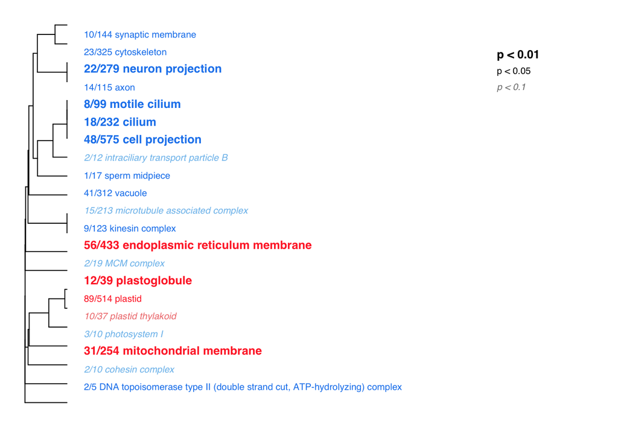

```
## GO terms dispayed:  21
## "Good genes" accounted for:  286 out of 781 ( 37% )
```

```r
results=gomwuPlot(input,goAnnotations,goDivision_3,
    absValue=-log(0.05,10),
    level1=0.1,
    level2=0.05,
    level3=0.01,
    txtsize=1.2,
    treeHeight=0.5,
    colors=c("dodgerblue2","firebrick1","skyblue2","lightcoral")
)
```

```r
results
```

```
##                                                                                    pval
## 2/5 DNA topoisomerase type II (double strand cut, ATP-hydrolyzing) complex 2.077971e-02
## 2/10 cohesin complex                                                       5.149143e-02
## 31/254 mitochondrial membrane                                              6.729819e-03
## 3/10 photosystem I                                                         8.622936e-02
## 10/37 plastid thylakoid                                                    8.622936e-02
## 89/514 plastid                                                             1.826674e-02
## 12/39 plastoglobule                                                        6.729819e-03
## 2/19 MCM complex                                                           6.040891e-02
## 56/433 endoplasmic reticulum membrane                                      2.761336e-03
## 9/123 kinesin complex                                                      1.253725e-02
## 15/213 microtubule associated complex                                      5.325010e-02
## 41/312 vacuole                                                             2.077971e-02
## 1/17 sperm midpiece                                                        1.826674e-02
## 2/12 intraciliary transport particle B                                     8.811215e-02
## 48/575 cell projection                                                     1.621564e-05
## 18/232 cilium                                                              2.761336e-03
## 8/99 motile cilium                                                         4.547206e-03
## 14/115 axon                                                                2.158815e-02
## 22/279 neuron projection                                                   6.729819e-03
## 23/325 cytoskeleton                                                        2.060605e-02
## 10/144 synaptic membrane                                                   3.200391e-02
##                                                                            direction
## 2/5 DNA topoisomerase type II (double strand cut, ATP-hydrolyzing) complex         0
## 2/10 cohesin complex                                                               0
## 31/254 mitochondrial membrane                                                      1
## 3/10 photosystem I                                                                 0
## 10/37 plastid thylakoid                                                            1
## 89/514 plastid                                                                     1
## 12/39 plastoglobule                                                                1
## 2/19 MCM complex                                                                   0
## 56/433 endoplasmic reticulum membrane                                              1
## 9/123 kinesin complex                                                              0
## 15/213 microtubule associated complex                                              0
## 41/312 vacuole                                                                     0
## 1/17 sperm midpiece                                                                0
## 2/12 intraciliary transport particle B                                             0
## 48/575 cell projection                                                             0
## 18/232 cilium                                                                      0
## 8/99 motile cilium                                                                 0
```

[output cut: 11 more lines]

```
## 12/39 plastoglobule                                                         firebrick1
## 2/19 MCM complex                                                              skyblue2
## 56/433 endoplasmic reticulum membrane                                       firebrick1
## 9/123 kinesin complex                                                      dodgerblue2
## 15/213 microtubule associated complex                                         skyblue2
## 41/312 vacuole                                                             dodgerblue2
## 1/17 sperm midpiece                                                        dodgerblue2
## 2/12 intraciliary transport particle B                                        skyblue2
## 48/575 cell projection                                                     dodgerblue2
## 18/232 cilium                                                              dodgerblue2
## 8/99 motile cilium                                                         dodgerblue2
## 14/115 axon                                                                dodgerblue2
## 22/279 neuron projection                                                   dodgerblue2
## 23/325 cytoskeleton                                                        dodgerblue2
## 10/144 synaptic membrane                                                   dodgerblue2
```

## Conclusion

Our analysis of differetially expressed genes in Clade C Symbiodiniaceae *in hospite* under extreme ocean acidification conditions revealed provides insight into the cellular response of the symbiont under acidification stress. Upon stringent analysis of differentially expressed genes revealed 14 genes upregulated and 3 genes downregulated. From analysis of the enriched cellular compartment (CC) GO terms, we identified the mitochondria as an important regulator of the acidification stress response in Clade C Symbiodiniaceae *in hospite.* In agreement with the Davies et al., 2018 paper upon which we based this study, gene expression (under stringent analysis) does not vary greatly within the symbiont under acidification stress. This may be due to the fact that the symbiont responds on a physiological level, adjusting macromolecule function instead of transcriptional regulation, which is in contrast to what researchers have observed in the host under acidification stress.